# Workshop - Temporal and Spatial Autocorrelation

Xanthe Walker

2025-08-05

## Introduction

In this workshop, we will explore how to detect and model temporal and spatial autocorrelation in ecological data.

For each example, we will:

1. Fit a model without autocorrelation
2. Check for autocorrelation
3. Fit and compare models with different correlation structures
4. Select the best correlation structure using AIC
5. Apply the selected correlation structure and continue with fixed effect selection

## Part 1: Temporal Autocorrelation

Load Hawaii dataset

```r
Hawaii <- read.csv("../../Data files/Hawaii.csv")
Hawaii$Birds <- sqrt(as.numeric(Hawaii$Moorhen.Kauai)) # transform abundance and only look at onbe species
head(Hawaii)
```

```
##   Year Stilt.Oahu Stilt.Maui Coot.Oahu Coot.Maui Moorhen.Kauai Rainfall
## 1 1956        163        169       528       177             2    15.16
## 2 1957        272        190       338       273            NA    15.48
## 3 1958        549        159       449       256             2    16.26
## 4 1959        533        211       822       170            10    21.25
## 5 1960         NA        232        NA       188             4    10.94
## 6 1961        134        155       717       149            10    19.93
##      Birds
## 1 1.414214
## 2       NA
## 3 1.414214
## 4 3.162278
## 5 2.000000
## 6 3.162278
```

```r
# Remove missing data
Hawaii <- Hawaii %>%
  filter(!is.na(Birds), !is.na(Rainfall), !is.na(Year))
```

### Step 1: Plot the data

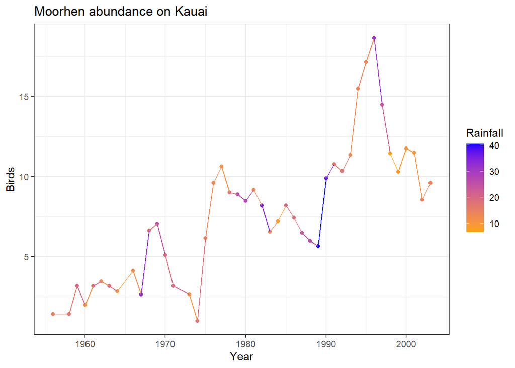

```r
ggplot(Hawaii, aes(x = Year, y = Birds, color = Rainfall)) +
  geom_point() +
  geom_line() +
  scale_color_gradient(low = "orange", high = "blue") +
  theme_bw() +
  labs(title = "Moorhen abundance on Kauai")
```

### Step 2: Fit a GLS model without correlation structure

We use gls() instead of lm() so we can later add correlation structures and compare models with the same fitting method (MLE).

```r
birds_gls <- gls(Birds ~ Rainfall + Year,
                 data = Hawaii,
                 na.action = na.omit,
                 method = "ML")
tab_model(birds_gls, show.aic = TRUE, show.se = TRUE)
```

|  | Birds |  |  |  |
| --- | --- | --- | --- | --- |
| Predictors | Estimates | std. Error | CI | p |
| (Intercept) | -477.66 | 56.42 | -591.52 – -363.81 | **<0.001** |
| Rainfall | 0.00 | 0.05 | -0.10 – 0.10 | 0.986 |
| Year | 0.25 | 0.03 | 0.19 – 0.30 | **<0.001** |
| Observations | 45 |  |  |  |
| R<sup>2</sup> | 0.638 |  |  |  |
| AIC | 218.886 |  |  |  |

### Step 3: Check residuals for autocorrelation

First, plot residuals vs. time.

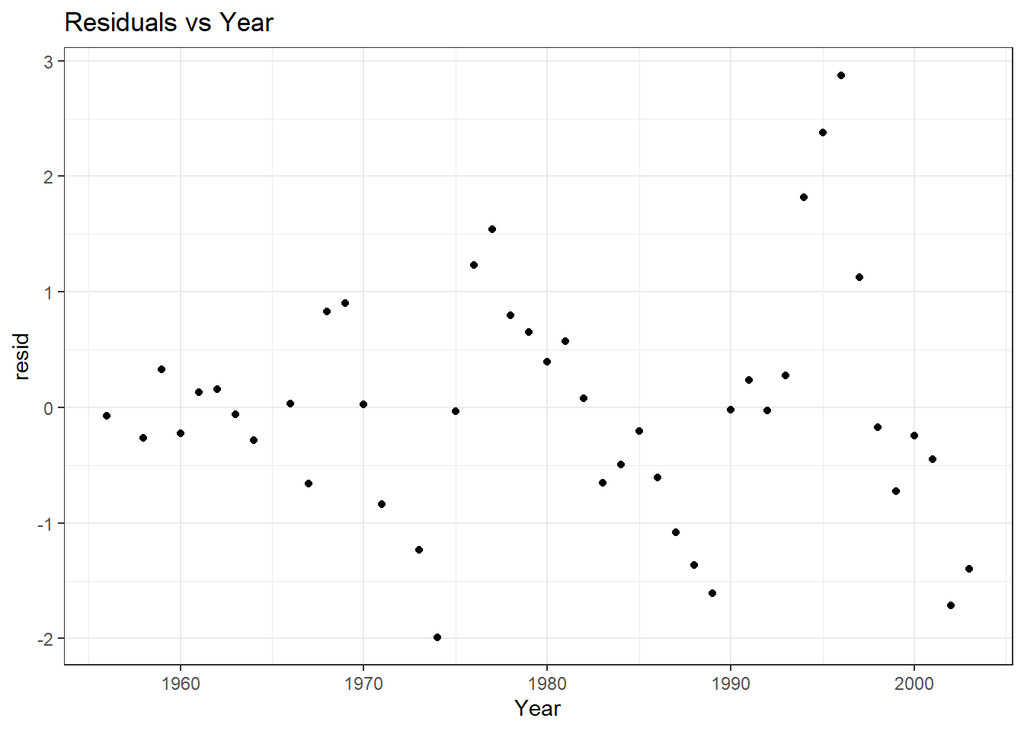

```r
Hawaii$resid <- residuals(birds_gls, type = "normalized")
ggplot(Hawaii, aes(x = Year, y = resid)) +
  geom_point() +
  theme_bw() +
  labs(title = "Residuals vs Year")
```

The plot of residuals vs. year shows a clear pattern — large positive residuals cluster in the 1990s, while negative residuals appear in the 1970s and early 2000s.  
This violates the assumption of independence because residuals close in time appear more similar.

Then, use the autocorrelation function (ACF) and partial autocorrelation function (PACF).

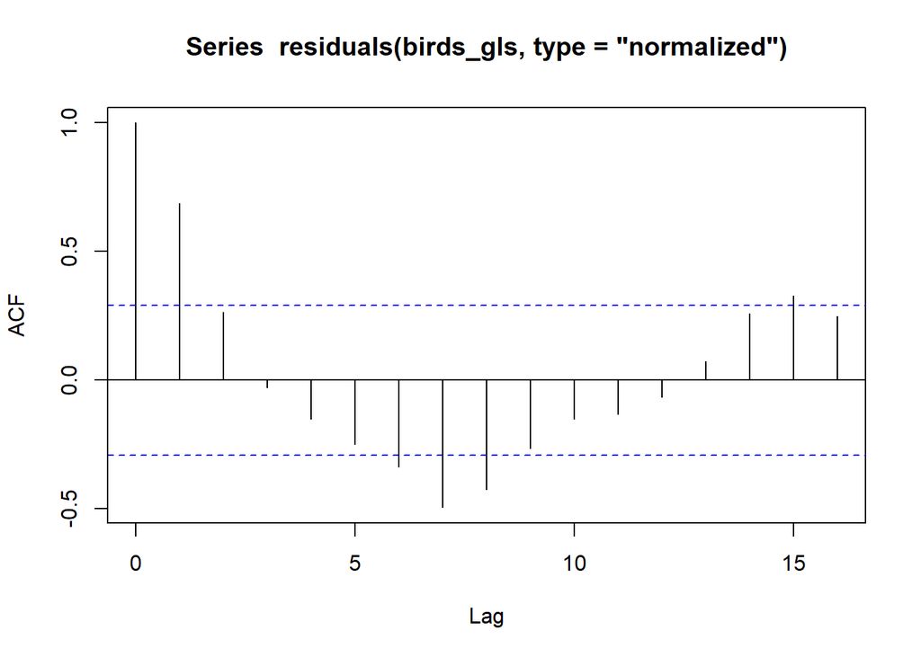

```r
acf(residuals(birds_gls, type = "normalized"))
```

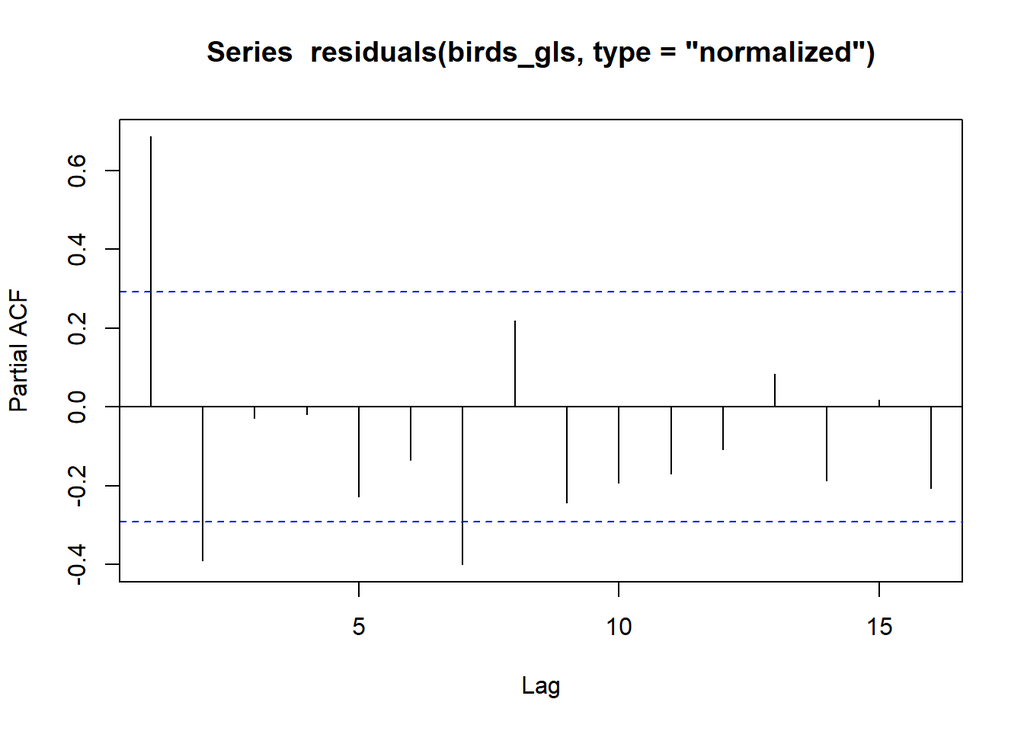

```r
pacf(residuals(birds_gls, type = "normalized"))
```

Together, these diagnostics tell us: - Observations are **not independent in time**. - We should test correlation structures such as AR(1), CAR(1), or ARMA to address this.

### Step 4: Fit models with different temporal correlation structures

Compound symmetry (constant correlation)

```r
birds_cs <- update(birds_gls,
                   correlation = corCompSymm(form = ~ Year))
```

AR(1) structure

```r
birds_ar1 <- update(birds_gls,
                    correlation = corAR1(form = ~ Year))
```

Continuous-time AR(1)

```r
birds_car1 <- update(birds_gls,
                     correlation = corCAR1(form = ~ Year))
```

ARMA(2,0) structure

```r
birds_arma20 <- update(birds_gls,
                       correlation = corARMA(form = ~ Year, p = 2, q = 0))
```

### Step 5: Compare temporal correlation structures

```r
AIC(birds_gls, birds_cs, birds_ar1, birds_car1, birds_arma20)
```

```
##              df      AIC
## birds_gls     4 218.8858
## birds_cs      5 194.8577
## birds_ar1     5 192.0444
## birds_car1    5 192.0444
## birds_arma20  6 187.9519
```

Choose the lowest AIC as the best-supported correlation structure.

### Step 6: Check residuals of best model

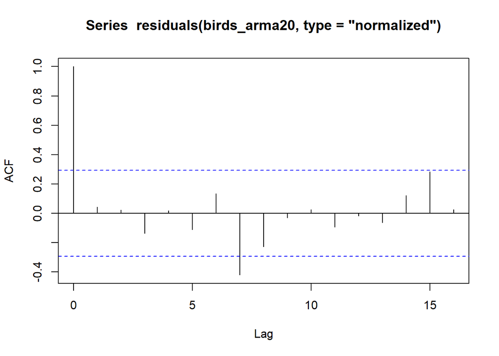

```r
acf(residuals(birds_arma20, type = "normalized"))
```

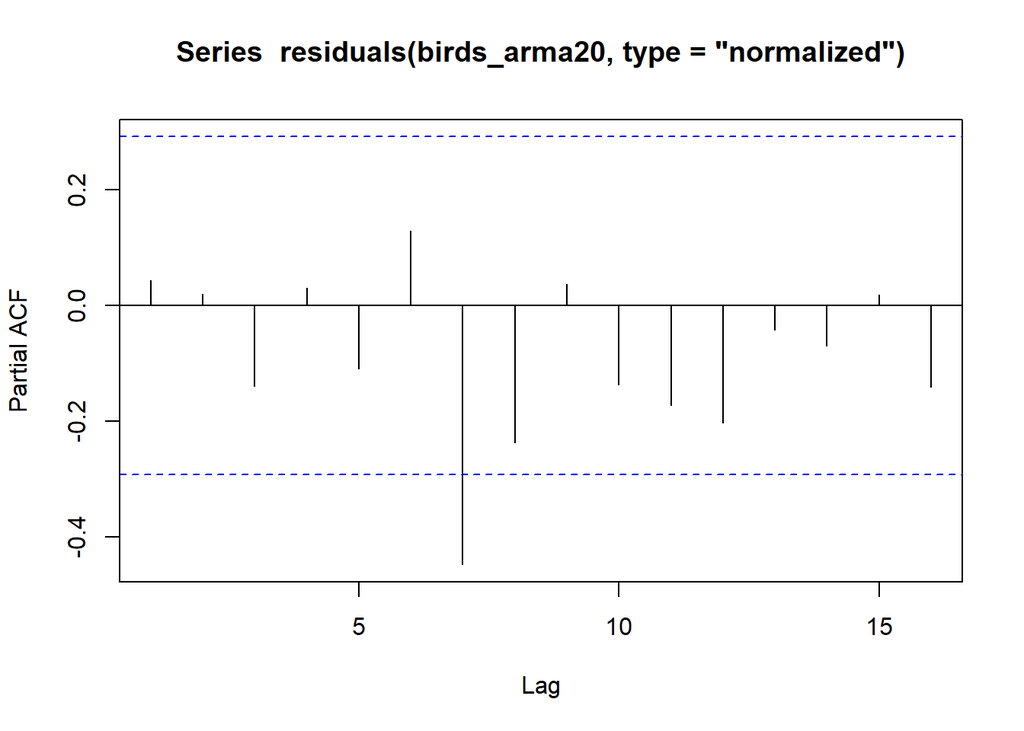

```r
pacf(residuals(birds_arma20 , type = "normalized"))
```

## Part 2: Modeling with many time series

### Load and reshape Hawaii dataset

```r
Hawaii1 <- read.csv("../../Data files/Hawaii.csv")
head(Hawaii1)
```

```
##   Year Stilt.Oahu Stilt.Maui Coot.Oahu Coot.Maui Moorhen.Kauai Rainfall
## 1 1956        163        169       528       177             2    15.16
## 2 1957        272        190       338       273            NA    15.48
## 3 1958        549        159       449       256             2    16.26
## 4 1959        533        211       822       170            10    21.25
## 5 1960         NA        232        NA       188             4    10.94
## 6 1961        134        155       717       149            10    19.93
```

```r
#reshape the data into long format
library(tidyr)
Hawaii_long <- Hawaii1 %>%
  pivot_longer(
    cols = Stilt.Oahu:Moorhen.Kauai,   # all bird columns
    names_to = "Species",              # new column for species/location
    values_to = "Count"                # new column for counts
  )

head(Hawaii_long)
```

```
## # A tibble: 6 × 4
##    Year Rainfall Species       Count
##   <int>    <dbl> <chr>         <int>
## 1  1956     15.2 Stilt.Oahu      163
## 2  1956     15.2 Stilt.Maui      169
## 3  1956     15.2 Coot.Oahu       528
## 4  1956     15.2 Coot.Maui       177
## 5  1956     15.2 Moorhen.Kauai     2
## 6  1957     15.5 Stilt.Oahu      272
```

```r
Hawaii_long=na.omit(Hawaii_long)
```

### Step 1: Plot the data

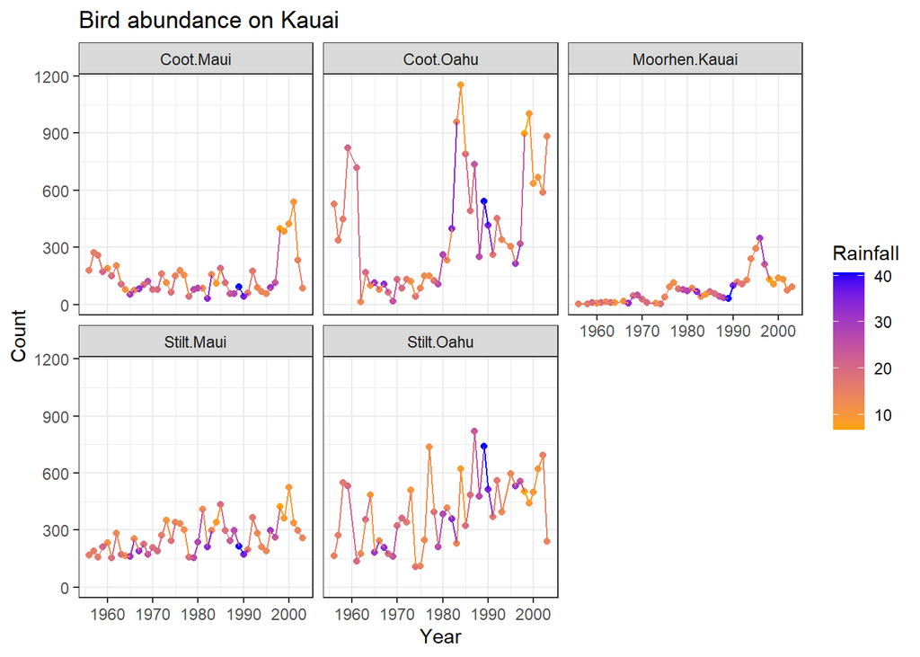

```r
ggplot(Hawaii_long, aes(x = Year, y = Count, color = Rainfall)) +
  geom_point() +
  geom_line() +
  facet_wrap(~Species)+
  scale_color_gradient(low = "orange", high = "blue") +
  theme_bw() +
  labs(title = "Bird abundance on Kauai")
```

We also see that variance appears to differ between species — this is heteroscedasticity.  
A single variance assumption would not be appropriate, so we’ll later model species-specific variances.

### Step 2: Fit GLS models

Without variance structure:

```r
birds_gls <- gls(Count ~ Rainfall*Species + Year,
                 data = Hawaii_long,
                 na.action = na.omit,
                 method = "ML")
tab_model(birds_gls, show.aic = TRUE, show.se = TRUE)
```

|  | Count |  |  |  |
| --- | --- | --- | --- | --- |
| Predictors | Estimates | std. Error | CI | p |
| (Intercept) | -9225.92 | 1491.94 | -12166.09 – -6285.75 | **<0.001** |
| Rainfall | -6.40 | 2.93 | -12.16 – -0.63 | **0.030** |
| Species [Coot.Oahu] | 267.97 | 83.84 | 102.75 – 433.20 | **0.002** |
| Species [Moorhen.Kauai] | -192.03 | 83.72 | -357.02 – -27.05 | **0.023** |
| Species [Stilt.Maui] | 83.88 | 82.71 | -79.12 – 246.88 | 0.312 |
| Species [Stilt.Oahu] | 130.66 | 83.84 | -34.57 – 295.88 | 0.121 |
| Year | 4.79 | 0.75 | 3.31 – 6.28 | **<0.001** |
| Rainfall × Species [Coot.Oahu] | -1.67 | 4.17 | -9.88 – 6.55 | 0.690 |
| Rainfall × Species [Moorhen.Kauai] | 6.50 | 4.20 | -1.79 – 14.79 | 0.124 |
| Rainfall × Species [Stilt.Maui] | 1.77 | 4.14 | -6.38 – 9.93 | 0.669 |
| Rainfall × Species [Stilt.Oahu] | 6.79 | 4.17 | -1.42 – 15.00 | 0.105 |
| Observations | 233 |  |  |  |
| R<sup>2</sup> | 0.481 |  |  |  |
| AIC | 3032.621 |  |  |  |

With species-specific variance:

```r
birds_var <- varIdent(form = ~ 1 | Species)
all_var <- gls(Count ~ Rainfall*Species + Year,
               data = Hawaii_long,
               weights = birds_var,
               na.action = na.omit)
tab_model(all_var, show.aic = TRUE, show.se = TRUE)
```

|  | Count |  |  |  |
| --- | --- | --- | --- | --- |
| Predictors | Estimates | std. Error | CI | p |
| (Intercept) | -6467.49 | 797.07 | -8038.28 – -4896.70 | **<0.001** |
| Rainfall | -6.49 | 1.79 | -10.03 – -2.95 | **<0.001** |
| Species [Coot.Oahu] | 268.95 | 115.08 | 42.16 – 495.75 | **0.020** |
| Species [Moorhen.Kauai] | -191.51 | 41.83 | -273.94 – -109.08 | **<0.001** |
| Species [Stilt.Maui] | 83.88 | 43.17 | -1.20 – 168.96 | 0.053 |
| Species [Stilt.Oahu] | 131.63 | 73.00 | -12.23 – 275.49 | 0.073 |
| Year | 3.40 | 0.40 | 2.61 – 4.19 | **<0.001** |
| Rainfall × Species [Coot.Oahu] | -1.71 | 5.69 | -12.93 – 9.51 | 0.764 |
| Rainfall × Species [Moorhen.Kauai] | 6.55 | 2.10 | 2.41 – 10.68 | **0.002** |
| Rainfall × Species [Stilt.Maui] | 1.77 | 2.16 | -2.48 – 6.03 | 0.412 |
| Rainfall × Species [Stilt.Oahu] | 6.75 | 3.62 | -0.38 – 13.88 | 0.063 |
| Observations | 233 |  |  |  |
| R<sup>2</sup> | 0.473 |  |  |  |
| AIC | 2876.545 |  |  |  |

The first GLS model (`birds_gls`) assumes equal variance across all species.  
The second model (`all_var`) uses `varIdent` to estimate separate residual variances for each species.

If the AIC is lower for `all_var`, that supports including species-specific variances.  
This helps prevent species with naturally higher variation from having undue influence on the fit.

### Step 3: Check residuals for autocorrelation

First, plot residuals vs. time.

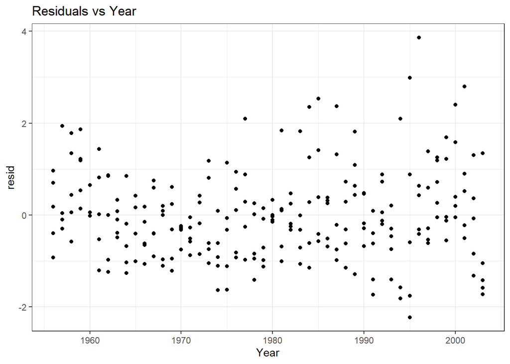

```r
Hawaii_long$resid <- residuals(all_var, type = "normalized")
ggplot(Hawaii_long, aes(x = Year, y = resid)) +
  geom_point() +
  theme_bw() +
  labs(title = "Residuals vs Year")
```

The residuals still show patterns over time, with clusters of positive or negative residuals.  
This suggests temporal autocorrelation remains after accounting for heterogeneity in variance.

Then, use the autocorrelation function (ACF) and partial autocorrelation function (PACF).

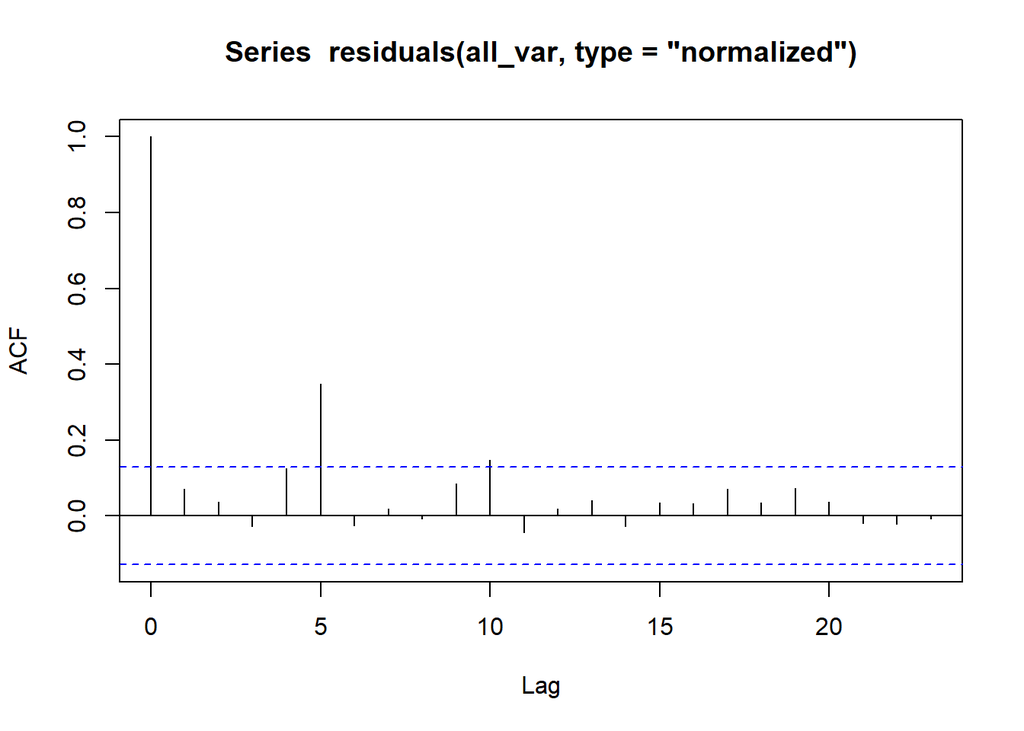

```r
acf(residuals(all_var, type = "normalized"))
```

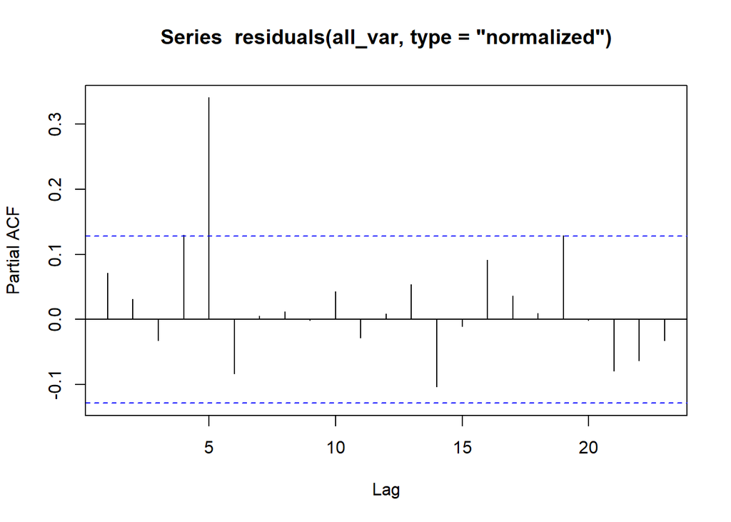

```r
pacf(residuals(all_var, type = "normalized"))
```

### Step 4: Fit models with different temporal correlation structures

Compound symmetry (constant correlation)

```r
birds_cs <- update(all_var,
                   correlation = corCompSymm(form = ~ Year|Species))
```

AR(1) structure

```r
birds_ar1 <- update(all_var,
                    correlation = corAR1(form = ~ Year|Species))
```

Continuous-time AR(1)

```r
birds_car1 <- update(all_var,
                     correlation = corCAR1(form = ~ Year|Species))
```

ARMA(2,0) structure

```r
birds_arma20 <- update(all_var,
                       correlation = corARMA(form = ~ Year|Species, p = 2, q = 0))
```

### Step 5: Compare temporal correlation structures

```r
AIC(all_var, birds_cs, birds_ar1, birds_car1, birds_arma20)
```

```
##              df      AIC
## all_var      16 2823.137
## birds_cs     17 2825.137
## birds_ar1    17 2752.718
## birds_car1   17 2752.718
## birds_arma20 18 2754.630
```

Both the **AR(1)** and **continuous AR(1)** structures improve the AIC dramatically (~70 points lower) compared to the model with no temporal correlation, indicating that residual autocorrelation is present and these models account for it well.

The ARMA(2,0) also improves AIC substantially but does not outperform AR(1).  
Compound symmetry increases AIC, so it is not supported.

Because AR(1) and continuous AR(1) give identical AIC here, we would choose **AR(1)** for simplicity and interpretability.

### Step 6: Check residuals of best model

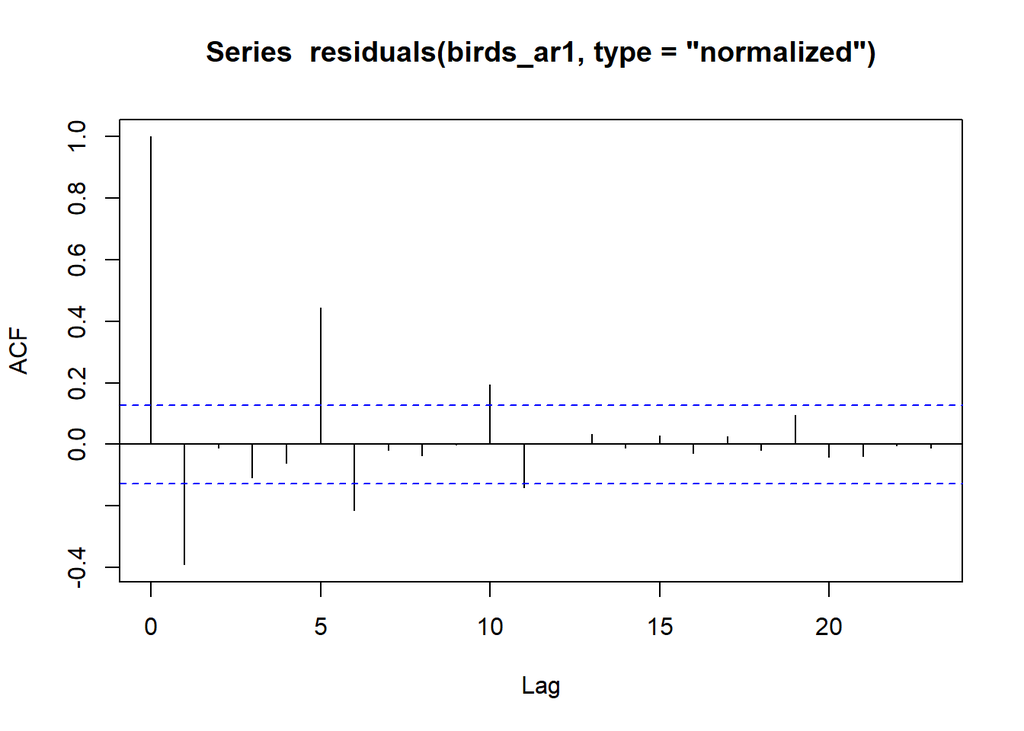

```r
acf(residuals(birds_ar1, type = "normalized"))
```

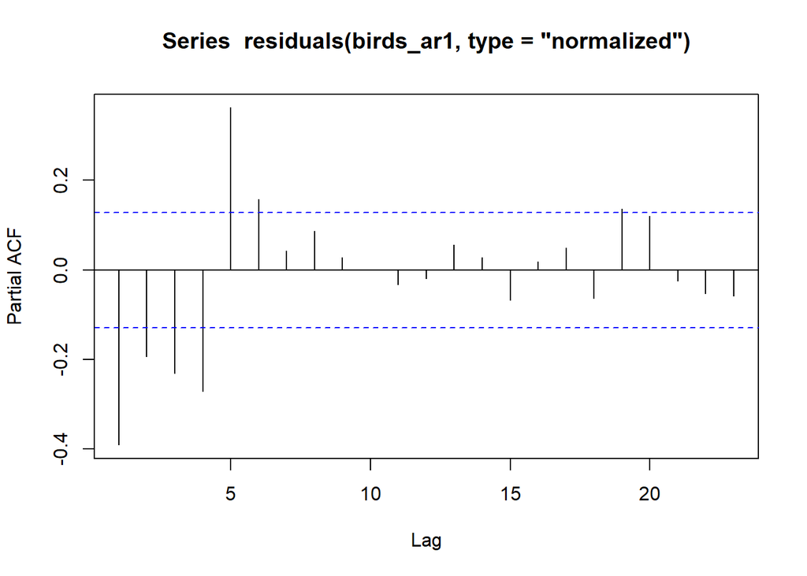

```r
pacf(residuals(birds_ar1 , type = "normalized"))
```

### Step 7: Plot the final model

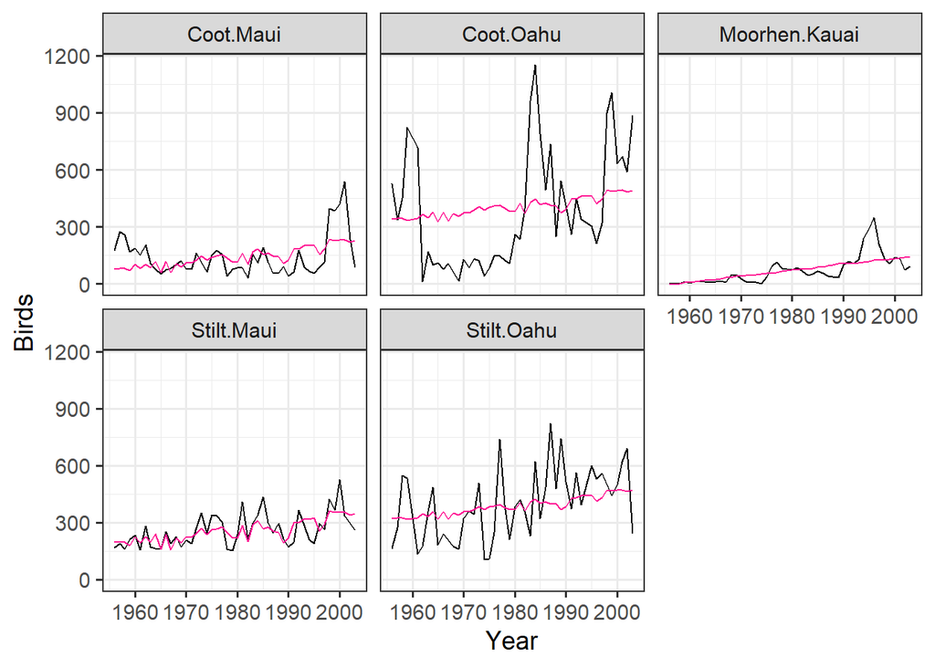

```r
Hawaii_long$fit <- predict(birds_ar1)

allSites <- ggplot(Hawaii_long,
       mapping=aes(x=Year, y=Count)) +
  geom_line() +
  theme_bw(base_size=14) +
  facet_wrap(~Species) +
  ylab("Birds")

allSites +
  geom_line(data=Hawaii_long,
            mapping=aes(y=fit),
            color="deeppink")
```

The pink lines show the model’s predicted values for each species over time. While the model captures the overall trends well, it smooths out some of the high interannual variability seen in the observed data (black lines), which is expected given the AR(1) correlation structure and inclusion of species-specific variance terms.

## Part 3: Spatial Autocorrelation

Load Boreality dataset

This dataset comes from a boreal forest in Tatarstan, Russia.

Response variable (Bor): Boreality index — calculated as the number of species belonging to a set of boreal species divided by the total number of species at a site.

Predictor variable (Wet): Wetness index — a measure of how wet or dry a site is.

```r
Boreality <- read.csv("../../Data files/Boreality.csv")
Boreality$Bor <- sqrt(1000 * (Boreality$nBor + 1) / (Boreality$nTot))
Boreality <- na.omit(Boreality)
```

### Step 1: Plot the data

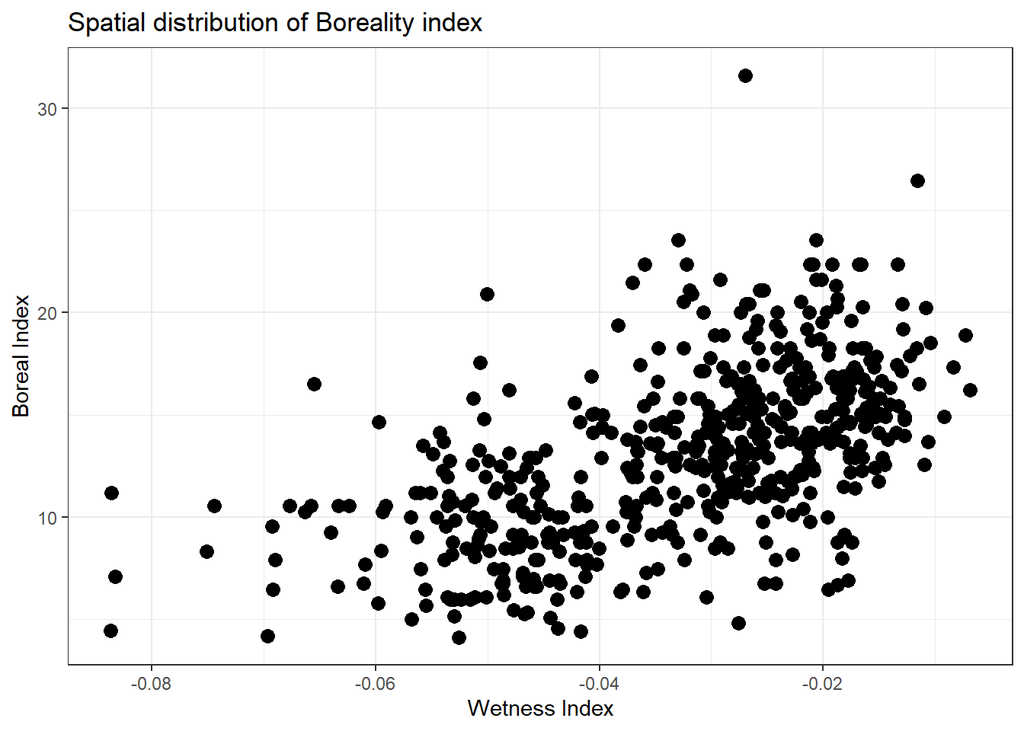

```r
ggplot(Boreality, aes(x = Wet, y = Bor)) +
  geom_point(size = 3) +
  theme_bw() +
  labs(
    title = "Spatial distribution of Boreality index",
    x = "Wetness Index",
    y = "Boreal Index"
  )
```

The scatterplot above shows a clear positive relationship: wetter sites tend to have higher boreality values. However, before we trust this relationship and move on with inference, we must check whether residuals from our model are spatially autocorrelated — because ignoring spatial correlation can bias standard errors and p‑values.

### Step 2: Fit a GLS model without spatial correlation

We first fit a generalized least squares (GLS) model without any spatial correlation structure. This acts as our baseline model for comparison.

```r
bor_gls <- gls(Bor ~ Wet, data = Boreality, method = "ML")
tab_model(bor_gls, show.aic = TRUE, show.se = TRUE)
```

|  | Bor |  |  |  |
| --- | --- | --- | --- | --- |
| Predictors | Estimates | std. Error | CI | p |
| (Intercept) | 18.49 | 0.38 | 17.74 – 19.23 | **<0.001** |
| Wet | 165.80 | 10.60 | 144.98 – 186.62 | **<0.001** |
| Observations | 533 |  |  |  |
| R<sup>2</sup> | 0.315 |  |  |  |
| AIC | 2849.156 |  |  |  |

### Step 3: Check residuals spatially

#### Bubble plot

We can visualize the residuals on the spatial coordinate system to see whether nearby sites have similar residual values.

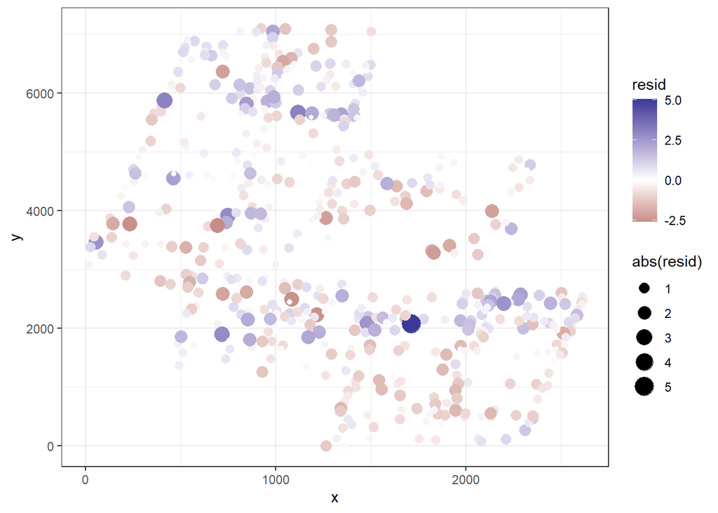

```r
Boreality$resid <- residuals(bor_gls, type = "normalized")
ggplot(Boreality, aes(x = x, y = y, color = resid, size = abs(resid))) +
  geom_point() +
  scale_color_gradient2() +
  theme_bw()
```

Interpretation:

- Red dots indicate negative residuals; blue dots indicate positive residuals.
- Dot size is proportional to the magnitude of the residuals (larger = greater deviation from the model prediction).
- Ideally, we should see no obvious spatial pattern — residuals should be randomly distributed across the study area.
- In this case, there appears to be some spatial clustering: many positive residuals occur close together, and the same is true for negative residuals.
- This suggests there may be spatial autocorrelation or a missing spatially structured predictor in the model.

#### Variogram

We can also use a variogram to check for spatial autocorrelation. The variogram measures the variability between pairs of observations at different distances.

If two sites are close to each other, and their residuals are similar, the semi-variance will be low → suggests spatial dependence.

If residuals are very different, the semi-variance will be high → suggests spatial independence.

The x-axis of the variogram plot shows the distance between site pairs, and the y-axis shows the semi-variance.

Key terms:

- Range: the distance at which spatial dependence disappears (variogram levels off).
- Sill: the semi-variance value at the range.
- Nugget: the semi-variance at zero distance, representing measurement error or variation at very small scales.

The nlme package includes a built-in Variogram() function to plot these.

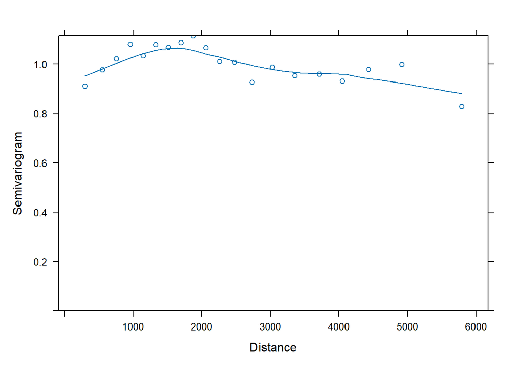

```r
vario_bor <- Variogram(bor_gls, form = ~ x + y, resType = "normalized")
plot(vario_bor)
```

#### Step 4: Fit models with different spatial correlation structures

Exponential

```r
bor_exp <- update(bor_gls,
                  correlation = corExp(form = ~ x + y, nugget = TRUE))
```

Gaussian

```r
bor_gaus <- update(bor_gls,
                   correlation = corGaus(form = ~ x + y, nugget = TRUE))
```

Linear

```r
#bor_lin <- update(bor_gls,
           #       correlation = corLin(form = ~ x + y, nugget = TRUE))
```

Ratio

```r
bor_ratio <- update(bor_gls,
                    correlation = corRatio(form = ~ x + y, nugget = TRUE))
```

Spherical

```r
bor_spher <- update(bor_gls,
                    correlation = corSpher(form = ~ x + y, nugget = TRUE))
```

#### Step 5: Compare spatial correlation structures

```r
AIC(bor_gls, bor_exp, bor_gaus, bor_ratio, bor_spher)
```

```
##           df      AIC
## bor_gls    3 2849.156
## bor_exp    5 2740.233
## bor_gaus   5 2743.595
## bor_ratio  5 2740.979
## bor_spher  5 2740.056
```

Select the lowest AIC model.

#### Step 6: Check residuals of best spatial model

Exponential is generally easier to excplain:

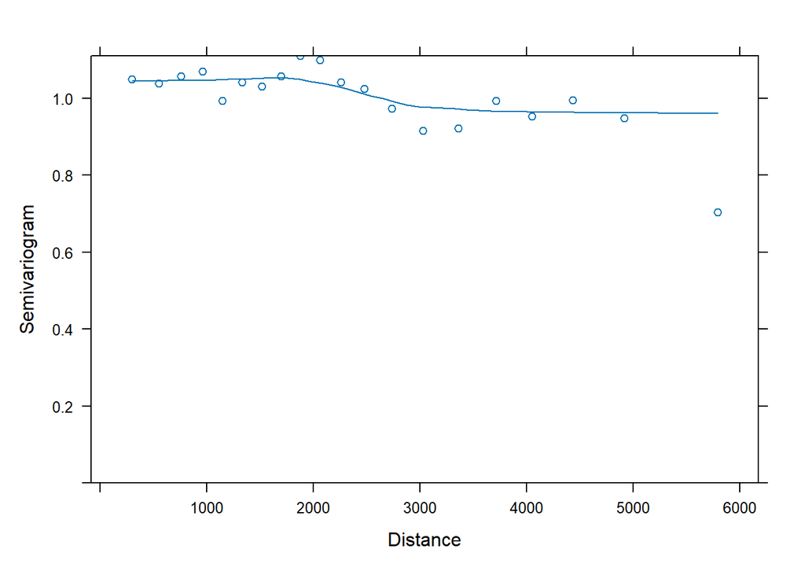

```r
vario_best <- Variogram(bor_exp, form = ~ x + y, resType = "normalized")
plot(vario_best)
```

A flat variogram after modeling indicates spatial independence.

## Exercises

### Exercise #1: Irish forest data

The data used are a subset of the data analysed in **Cruikshanks et al. (2006)**, a technical report by the Environmental Protection Agency, Wexford, Ireland.  
We only use the 2003 data, and several recordings were dropped.  
The original research sampled 257 rivers in Ireland during 2002 and 2003.  
One aim was to find a different tool for identifying acid-sensitive waters, which currently uses measures of pH.  
The Sodium Dominance Index (SDI) was proposed as an alternative.  
The motivation for this research is the increase in plantation forestry cover in Irish landscapes and its potential impacts on aquatic resources.

**Tasks:**

1. Read the data from `Irishforest.csv` and inspect the first few lines to ensure it was read correctly.
2. Pay careful attention to the following variables (pH is the response variable):
   - Sodium Dominance Index (SDI)
   - Status as forested or not
   - Altitude
3. Plot the data of pH and forested status in sampling space (Easting and Northing). Does there appear to be spatial correlation?
4. Fit a linear model with pH as a function of SDI, forested status, altitude, **all two-way interactions**, and the **three-way interaction**.
5. Examine model assumptions using residual plots.
6. Extract and plot the residuals spatially (colored by residual value). Are the residuals spatially correlated?
7. Plot a variogram to assess spatial correlation.
8. Add **at least two different spatial correlation structures** to the model.
9. Compare models with different spatial correlation structures using AIC. Make a table of AIC values.
10. Plot a variogram of the best model. Is the spatial correlation accounted for?
11. If not, describe your next steps.

### Exercise #2: Plankton / Cod dataset

Data from:  
Freitas, C., E. M. Olsen, H. Knutsen, J. Albretsen, and E. Moland. 2016.  
Temperature-associated habitat selection in a cold-water marine fish. *Journal of Animal Ecology* 85:628–637.

The authors examined the effect of ocean temperature on dive depth of individually tagged Atlantic cod along the Norwegian coast.

**Tasks:**

1. Read the data from `Cod_Daily_Depth.csv` and inspect the first few lines to ensure it was read correctly.
2. Examine the structure of the dataset.
3. Change the date column from `day/month/year` to `year-month-day` format using the `lubridate` package.
4. Plot log-transformed dive depth as a function of temperature for each fish. Why log-transform depth here?
5. Center the temperature predictor to reduce correlation between intercepts and slopes.
6. Fit a mixed-effects model predicting dive depth from centered surface temperature with:
   - Random intercept for `fish`
   - Random slope for `temperature_centered` grouped by `fish`
   - Use `nlme::lme` (not `lme4`) so that we can model residual correlation.
7. Examine the model fit. Plot fitted relationships for each fish.
8. Plot residuals versus fitted values for each fish.
9. Plot residuals versus date for each fish.
10. Use the autocorrelation function (ACF) to examine correlation of residuals between days. How correlated are values one day apart?
11. Add a temporal autocorrelation structure (`corAR1()`).
12. Examine the residuals versus fitted values and versus date again, using `type = "normalized"` residuals.
13. Plot the final fitted model.
    - Transform predictions from log(depth) back to depth for interpretation.
    - Use `ggpredict` for population-level predictions.
    - (**Bonus**) Plot a separate slope and intercept for each fish.

Note: The `corAR1()` correlation structure is just one of a number of temporal correlation structures we could have fit. It is the simplest, and probably most common to use. nmle allows us to also fit higher order auto regressive models in the residuals. For example, an AR2 model would also estimate a regression parameter for residuals that are 2 time steps apart. This, and possible moving average coefficients, can be estimated with the `nlme::corARMA()`.

Models with different correlation structures can be compared via AIC, and perhaps more importantly, by inspecting the residuals yourself with well-thought-out plots. Zuur et al. makes the point that fitting any temporal autocorrelation structure is usually far more important than getting the perfect structure. Start with AR1 and try more complicated structures if that seems insufficient.